# Airbnb Zurich

ESSHA KHAN

Open to opportunities

← All projects

Airbnb Zurich  
Data Mining & Analysis Project

01 DATA MINING PROJECT

# What shapes price, demand, and listing performance in Zurich's Airbnb market?

I analyzed Airbnb listings across Zurich to understand how neighborhood, room type, capacity, host quality, and booking behavior shape the market — then tested whether machine-learning models could uncover additional patterns in amenities, pricing, and listing segments.

PythonPandasData Cleaning VisualizationKNNDistilBERTK-Means

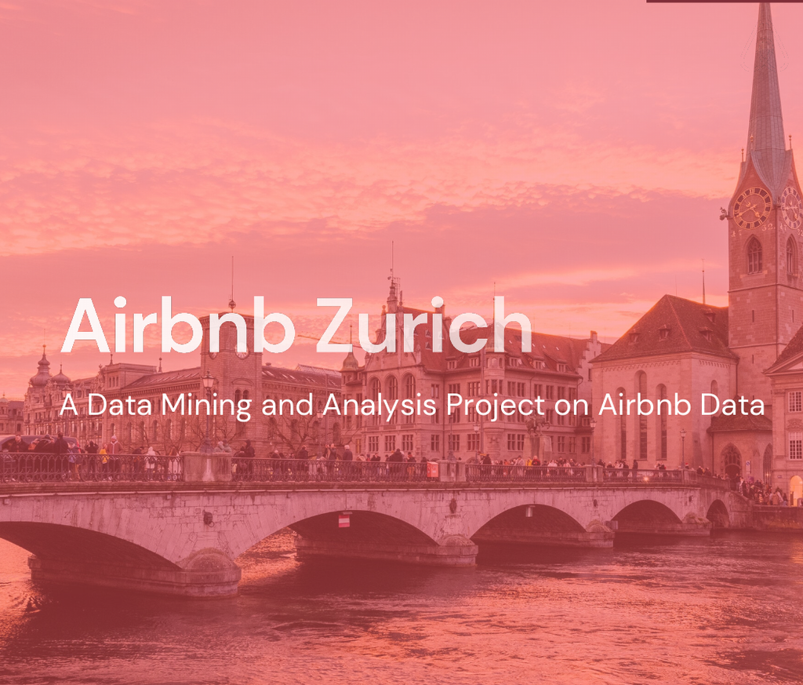

PROJECT QUESTIONS

## What did I want to understand?

01 — MARKET

### Where is Airbnb demand strongest?

Compare neighborhoods using price, booking activity, reviews, ratings, and room-type mix.

02 — PRICING

### What appears to drive higher prices?

Examine listing capacity, location, property characteristics, and the variation that remains within similar listings.

03 — HOST QUALITY

### How does hosting quality vary?

Explore superhost concentration and whether high-demand central areas show more professionalized hosting.

04 — MACHINE LEARNING

### Can models reveal useful listing patterns?

Test classification, transformer-based text modeling, and clustering on different aspects of the Zurich market.

02 PROCESSING & CLEANING

## Preparing a messy marketplace dataset for analysis

I treated missing values based on the meaning of each variable rather than applying one blanket imputation rule. Missing bathrooms, bedrooms, and beds were inferred using related listing information such as guest capacity; host response variables were cleaned and encoded; extreme bed and bedroom values were handled before modeling; text nulls were converted to empty strings for compatibility; and low-information or heavily missing fields were removed.

01**Audit missingness**

02**Context-aware imputation**

03**Clean & encode fields**

04**Handle extreme values**

05**Remove low-value features**

03 MARKET OVERVIEW

## Zurich is a high-price market with meaningful neighborhood differences

CHF 267.86

Highest average neighborhood price

4.83

Highest average rating

72.95

Most reviews on average

CHF 1,624.98

Widest observed price range

[figure not shown]

Neighborhood-level price, rating, review, and price-distribution comparisons from the project presentation.

[figure not shown]

Booking activity highlights meaningful differences in short-term demand across Zurich neighborhoods.

04 EXPLORATORY VISUAL ANALYSIS

## What do listing characteristics tell us about the market?

ROOM TYPE

### Entire homes dominate many high-demand areas

Entire homes and apartments make up much of the supply across Zurich. The presentation notes that central areas such as Langstrasse, Seefeld, and Altstadt show more entire-home rentals, while private and shared rooms appear more often in select peripheral areas.

[figure not shown]

Room type distribution by neighborhood.

HOST QUALITY

### Superhost concentration varies substantially by neighborhood

Central, tourism-heavy, and higher-demand neighborhoods show stronger superhost concentrations in the analysis, suggesting that competitive markets may push hosts toward more professional service standards.

[figure not shown]

Percentage of superhosts by neighborhood.

PRICE & CAPACITY

### Larger listings tend to cost more — but size is not the whole story

The analysis finds a positive relationship between guest capacity and price, alongside substantial price variation at each capacity level. Location, amenities, room type, and property quality therefore appear important alongside size.

[figure not shown]

Listing capacity versus price, colored by room type.

05 MACHINE LEARNING

## Testing structured and unstructured approaches

KNN CLASSIFICATION

### Parking availability

Used accommodates, bathrooms, bedrooms, beds, and price to classify whether a listing offered parking. The reported accuracy was 0.58 versus a 0.53 naive baseline.

TRANSFORMER

### Price quartile from text

Fine-tuned DistilBERT on listing description, host_about, and amenities to predict price quartile. The presentation reports validation accuracy around 0.442.

K-MEANS

### Listing segmentation

Clustered listings using price, accommodates, reviews, review score, and booking-demand variables to identify market segments.

[figure not shown]

KNN classification: parking availability was only modestly predictable from the selected listing features.

[figure not shown]

06 CLUSTERING ANALYSIS

## Segmenting Zurich listings into five market profiles

The K-Means analysis grouped listings using price, guest capacity, review volume, review score, and 30-day booking demand. The selected five-cluster solution was used to describe listing segments ranging from budget/high-occupancy supply to premium large-capacity listings.

[figure not shown]

The project selected five clusters after comparing K-Means inertia and balancing segmentation with interpretability.

[figure not shown]

Cluster-level comparisons show meaningful differences in average price, demand, and listing counts.

**What the clustering adds**

Rather than treating Zurich as one homogeneous Airbnb market, the segmentation reveals distinct combinations of price, capacity, popularity, and demand — useful for thinking about positioning and market strategy.

07 KEY TAKEAWAYS

## What did the analysis suggest?

MARKET STRUCTURE

### Location matters

Central areas combine stronger demand with higher prices, while outer neighborhoods tend to be more affordable and lower-demand.

PRICING

### Size helps, but does not explain everything

Capacity is positively related to price, but location, room type, amenities, and listing quality also contribute to the spread.

DEMAND

### Short-term demand is uneven

Booking activity differs across neighborhoods, with some central areas showing substantially stronger near-term demand.

LISTINGS

### Entire homes dominate

The Zurich market is heavily oriented toward entire-home rentals, particularly in central and higher-demand areas.

MODELING

### Predictive signal was mixed

KNN and transformer experiments found some signal, but neither selected feature set fully explained the target outcomes.

SEGMENTATION

### Five profiles reveal market structure

Clustering separated budget, high-demand, premium, and larger-capacity listing profiles with different strategic characteristics.

[figure not shown]

Summary of the project's main market, pricing, demand, listing, machine-learning, and strategic findings.